# Regression Analysis on House, BIST and Employment Statistics

## Data

```python
# Get unemployment data
unemp_df = evds.get_data(['TP.YISGUCU2.G8'],
              startdate="01-01-2016",
              enddate="01-01-2024",
              aggregation_types='avg',
              formulas=[0],
              frequency=5
                )

unemp_df = unemp_df.rename({'Tarih': 'Date', 'TP_YISGUCU2_G8': 'Unemployment Rate'}, axis=1)
unemp_df.loc[:, 'Date'] = pd.to_datetime(unemp_df['Date'])
unemp_df.to_csv('./Data/EVDS/unemployment.csv', index=False)
```

```python
unemp_df = pd.read_csv('./Data/EVDS/unemployment.csv')
unemp_df.loc[:, 'Date'] = pd.to_datetime(unemp_df['Date'])
```

```python
np.corrcoef(home_sale_df['Home Sales'], unemp_df['Unemployment Rate'])[0, 1]
```

```
0.016827630498199787
```

```python
np.corrcoef(bist_vol_df['BIST Volume'], unemp_df['Unemployment Rate'])[0, 1]
```

```
-0.24668687718719096
```

```python
# Read LinkedIn search data
linkdn_search_df = pd.read_csv('./Data/Google Trends/ggltrd_linkedin.csv', skiprows=1)
linkdn_search_df = linkdn_search_df.rename({'Ay':'Date', 'LinkedIn: (Türkiye)':'LinkedIn SS'}, axis=1)
linkdn_search_df.loc[:, 'Date'] = pd.to_datetime(linkdn_search_df['Date'])
```

```python
# Read job search data
job_search_df = pd.read_csv('./Data/Google Trends/ggltrd_isilani.csv', skiprows=1)
job_search_df = job_search_df.rename({'Ay':'Date', 'iş ilanı: (Türkiye)':'Job SS'}, axis=1)
job_search_df.loc[:, 'Date'] = pd.to_datetime(job_search_df['Date'])
```

```python
# Join the data for EDA
unemp_analysis_df = unemp_df.set_index('Date').join(linkdn_search_df.set_index('Date')).join(job_search_df.set_index('Date'))\
                        .join(usd_df.set_index('Date'))
```

### EDA

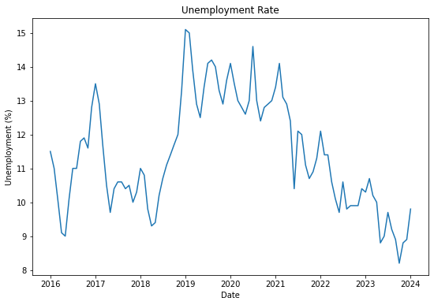

```python
plt.figure(figsize=(9, 6))
plt.plot(unemp_df['Date'], unemp_df['Unemployment Rate'])
plt.title('Unemployment Rate')
plt.xlabel('Date')
plt.ylabel('Unemployment (%)')
```

There seems to be a seasonality in the target variable and a regime change just before 2019. This new pattern seems to have a down trend.

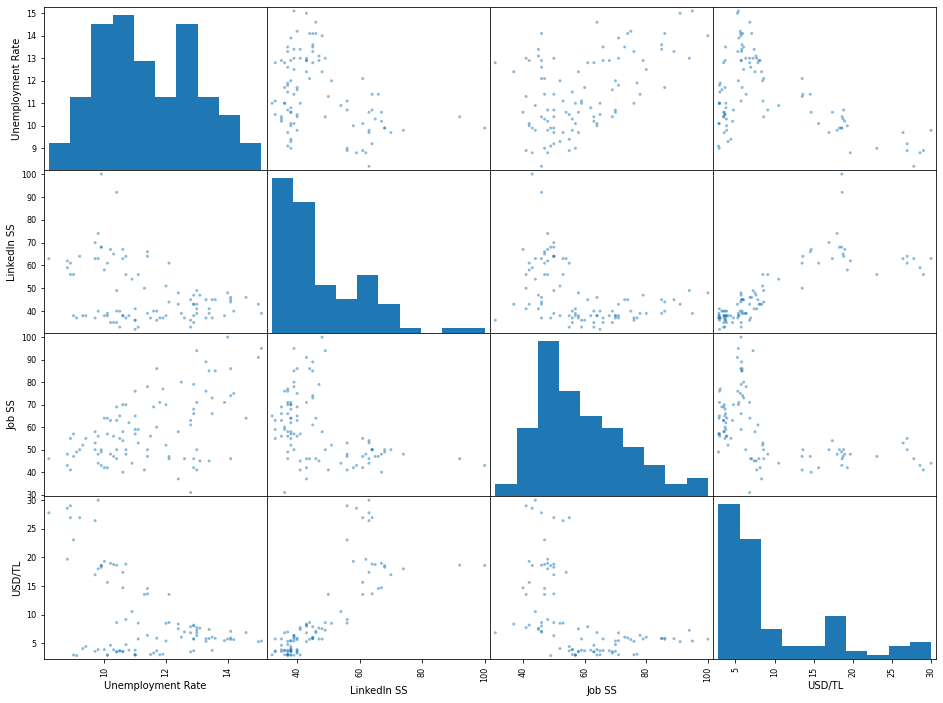

```python
pd.plotting.scatter_matrix(unemp_analysis_df, figsize=(16, 12))
plt.show()
```

There are linear relations between the target and the Linkedin search as well as Job search, however, there seems to be a non-linear relation with USD/TL. This relation seems to be exponential, so the feature transformation is needed for USD/TL.

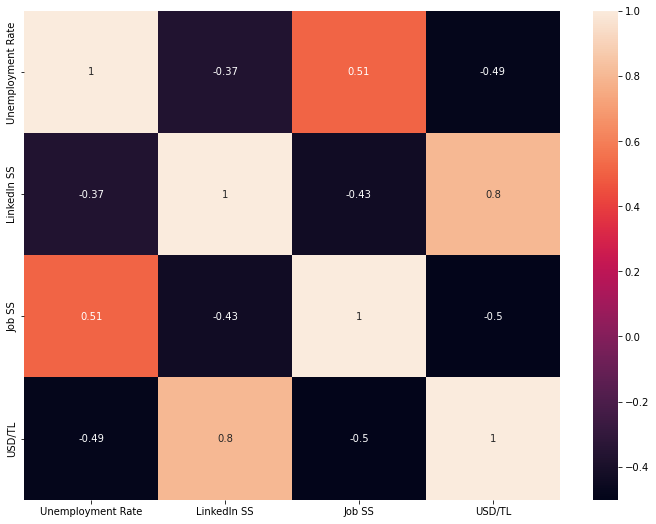

```python
# Correlation matrix
plt.figure(figsize=(12, 9))
sns.heatmap(unemp_analysis_df.corr(), annot=True)
```

There are decent correlation between the target and the features, and some features are highly correlated as well.

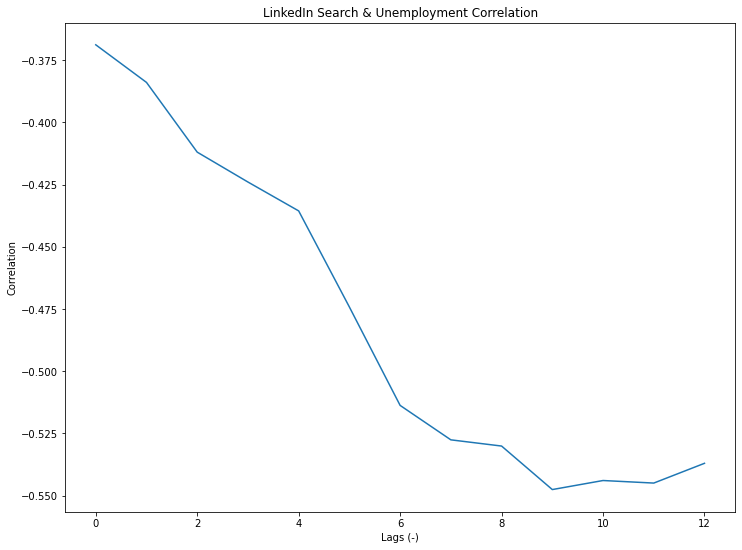

```python
best_lag_linkedin = get_best_lag(linkdn_search_df['LinkedIn SS'], unemp_df['Unemployment Rate'], lags=13,
                                x_label='Lags (-)', y_label='Correlation', title='LinkedIn Search & Unemployment Correlation')
```

```python
best_lag_linkedin
```

```
9
```

It makes sense that the people who are search for a job eventually find one and lower the target variable, however, 9 month time lag is relatively high.

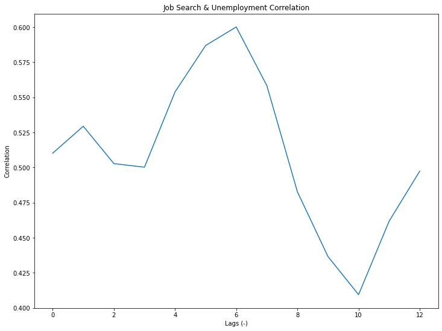

```python
best_lag_job = get_best_lag(job_search_df['Job SS'], unemp_df['Unemployment Rate'], lags=13,
                            x_label='Lags (-)', y_label='Correlation', title='Job Search & Unemployment Correlation')
```

```python
best_lag_job
```

```
6
```

This correlations are counterintuitive, however, it might be indicating that people who look for jobs with this fashion are likely to contribute to the unemployment on the long run (like 6 months).

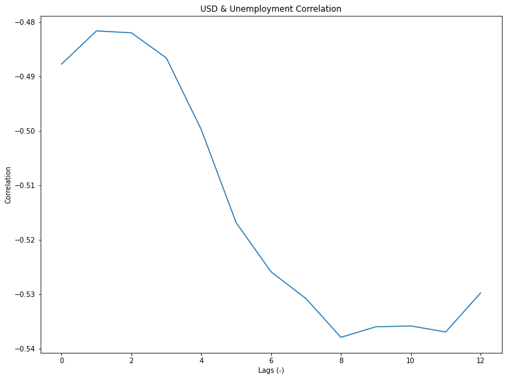

```python
best_lag_usd = get_best_lag(usd_df['USD/TL'], unemp_df['Unemployment Rate'], lags=13,
                            x_label='Lags (-)', y_label='Correlation', title='USD & Unemployment Correlation')
```

```python
best_lag_usd
```

```
8
```

This correlation plot makes sense because when USD increase, the salaries decrease and after some time companies look for new employees which also takes time to find. Also true when USD decrease, the salaries increase which leads to layoffs after some time.

```python
# Base X set
unemp_X = sm.add_constant(linkdn_search_df['LinkedIn SS'].shift(9).iloc[9:])
unemp_X['Job SS'] = job_search_df['Job SS'].shift(6).iloc[9:]
unemp_X['USD/TL'] = np.exp(-usd_df['USD/TL'].shift(8).iloc[9:])
unemp_X['Is Covid'] = covid_df['Covid Period'].iloc[9:]
unemp_X['trend'] = unemp_X.reset_index(drop=True).index
```

```python
unemp_lr = sm.OLS(unemp_df['Unemployment Rate'].iloc[9:], unemp_X)
unemp_lr = unemp_lr.fit()
unemp_lr.summary()
```

OLS Regression Results

| Dep. Variable: | Unemployment Rate | R-squared: | 0.593 |
| --- | --- | --- | --- |
| Model: | OLS | Adj. R-squared: | 0.568 |
| Method: | Least Squares | F-statistic: | 23.85 |
| Date: | Fri, 05 Apr 2024 | Prob (F-statistic): | 9.97e-15 |
| Time: | 15:26:25 | Log-Likelihood: | -130.29 |
| No. Observations: | 88 | AIC: | 272.6 |
| Df Residuals: | 82 | BIC: | 287.4 |
| Df Model: | 5 |  |  |
| Covariance Type: | nonrobust |  |  |

|  | coef | std err | t | P>\|t\| | [0.025 | 0.975] |
| --- | --- | --- | --- | --- | --- | --- |
| const | 12.1235 | 1.165 | 10.402 | 0.000 | 9.805 | 14.442 |
| LinkedIn SS | -0.0175 | 0.020 | -0.885 | 0.379 | -0.057 | 0.022 |
| Job SS | 0.0411 | 0.010 | 4.069 | 0.000 | 0.021 | 0.061 |
| USD/TL | -59.6099 | 16.501 | -3.613 | 0.001 | -92.435 | -26.785 |
| Is Covid | 0.7609 | 0.313 | 2.430 | 0.017 | 0.138 | 1.384 |
| trend | -0.0415 | 0.017 | -2.494 | 0.015 | -0.075 | -0.008 |

| Omnibus: | 2.066 | Durbin-Watson: | 0.539 |
| --- | --- | --- | --- |
| Prob(Omnibus): | 0.356 | Jarque-Bera (JB): | 1.631 |
| Skew: | 0.329 | Prob(JB): | 0.443 |
| Kurtosis: | 3.114 | Cond. No. | 1.25e+04 |

Notes:  
[1] Standard Errors assume that the covariance matrix of the errors is correctly specified.  
[2] The condition number is large, 1.25e+04. This might indicate that there are  
strong multicollinearity or other numerical problems.

Low Adjusted R^2 value, the Linkedin search seems to be not significant while other features are significant.

```python
unemp_res_arr = unemp_lr.resid
```

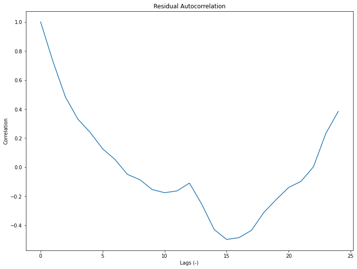

```
0
```

```python
get_best_lag(unemp_res_arr, unemp_res_arr, lags=25, x_label='Lags (-)', y_label='Correlation', title='Residual Autocorrelation')
```

There seems so be a little seasonality.

```python
unemp_X = unemp_X.join(pd.get_dummies(pd.to_datetime(linkdn_search_df.iloc[9:, 0]).dt.month).astype(int))
```

```python
unemp_lr = sm.OLS(unemp_df['Unemployment Rate'].iloc[9:], unemp_X)
unemp_lr = unemp_lr.fit()
unemp_lr.summary()
```

OLS Regression Results

| Dep. Variable: | Unemployment Rate | R-squared: | 0.690 |
| --- | --- | --- | --- |
| Model: | OLS | Adj. R-squared: | 0.620 |
| Method: | Least Squares | F-statistic: | 9.884 |
| Date: | Fri, 05 Apr 2024 | Prob (F-statistic): | 2.07e-12 |
| Time: | 15:26:25 | Log-Likelihood: | -118.23 |
| No. Observations: | 88 | AIC: | 270.5 |
| Df Residuals: | 71 | BIC: | 312.6 |
| Df Model: | 16 |  |  |
| Covariance Type: | nonrobust |  |  |

|  | coef | std err | t | P>\|t\| | [0.025 | 0.975] |
| --- | --- | --- | --- | --- | --- | --- |
| const | 10.9360 | 1.138 | 9.613 | 0.000 | 8.668 | 13.204 |
| LinkedIn SS | 0.0065 | 0.020 | 0.326 | 0.745 | -0.033 | 0.047 |
| Job SS | 0.0397 | 0.011 | 3.555 | 0.001 | 0.017 | 0.062 |
| USD/TL | -69.4986 | 16.735 | -4.153 | 0.000 | -102.868 | -36.129 |
| Is Covid | 1.0710 | 0.304 | 3.518 | 0.001 | 0.464 | 1.678 |
| trend | -0.0585 | 0.017 | -3.400 | 0.001 | -0.093 | -0.024 |
| 1 | 1.8860 | 0.383 | 4.919 | 0.000 | 1.122 | 2.650 |
| 2 | 1.8056 | 0.401 | 4.502 | 0.000 | 1.006 | 2.605 |
| 3 | 0.8364 | 0.412 | 2.030 | 0.046 | 0.015 | 1.658 |
| 4 | 0.2580 | 0.414 | 0.623 | 0.535 | -0.567 | 1.083 |
| 5 | 0.1358 | 0.388 | 0.350 | 0.727 | -0.638 | 0.909 |
| 6 | 0.2046 | 0.389 | 0.525 | 0.601 | -0.572 | 0.981 |
| 7 | 1.0638 | 0.387 | 2.747 | 0.008 | 0.292 | 1.836 |
| 8 | 0.6304 | 0.405 | 1.557 | 0.124 | -0.177 | 1.438 |
| 9 | 0.7610 | 0.376 | 2.022 | 0.047 | 0.011 | 1.511 |
| 10 | 1.1657 | 0.359 | 3.243 | 0.002 | 0.449 | 1.882 |
| 11 | 0.9708 | 0.356 | 2.725 | 0.008 | 0.260 | 1.681 |
| 12 | 1.2178 | 0.374 | 3.253 | 0.002 | 0.471 | 1.964 |

| Omnibus: | 0.298 | Durbin-Watson: | 0.478 |
| --- | --- | --- | --- |
| Prob(Omnibus): | 0.862 | Jarque-Bera (JB): | 0.427 |
| Skew: | -0.123 | Prob(JB): | 0.808 |
| Kurtosis: | 2.764 | Cond. No. | 1.32e+18 |

Notes:  
[1] Standard Errors assume that the covariance matrix of the errors is correctly specified.  
[2] The smallest eigenvalue is 3.99e-31. This might indicate that there are  
strong multicollinearity problems or that the design matrix is singular.

Manually dropping non-significant features can increase the robostness of the model.

```python
# p > .5 features eliminated manually after each feature adding iteration => To increase robustness & eliminate some of the correlated features
unemp_lr = sm.OLS(unemp_df['Unemployment Rate'].iloc[9:], unemp_X.drop(['LinkedIn SS', 4, 5, 6], axis=1))
unemp_lr = unemp_lr.fit()
unemp_lr.summary()
```

OLS Regression Results

| Dep. Variable: | Unemployment Rate | R-squared: | 0.690 |
| --- | --- | --- | --- |
| Model: | OLS | Adj. R-squared: | 0.635 |
| Method: | Least Squares | F-statistic: | 12.64 |
| Date: | Fri, 05 Apr 2024 | Prob (F-statistic): | 5.15e-14 |
| Time: | 15:26:25 | Log-Likelihood: | -118.33 |
| No. Observations: | 88 | AIC: | 264.7 |
| Df Residuals: | 74 | BIC: | 299.3 |
| Df Model: | 13 |  |  |
| Covariance Type: | nonrobust |  |  |

|  | coef | std err | t | P>\|t\| | [0.025 | 0.975] |
| --- | --- | --- | --- | --- | --- | --- |
| const | 11.1953 | 1.204 | 9.301 | 0.000 | 8.797 | 13.594 |
| Job SS | 0.0402 | 0.011 | 3.749 | 0.000 | 0.019 | 0.062 |
| USD/TL | -66.6972 | 14.239 | -4.684 | 0.000 | -95.069 | -38.326 |
| Is Covid | 1.0283 | 0.268 | 3.842 | 0.000 | 0.495 | 1.562 |
| trend | -0.0540 | 0.010 | -5.163 | 0.000 | -0.075 | -0.033 |
| 1 | 1.6536 | 0.424 | 3.901 | 0.000 | 0.809 | 2.498 |
| 2 | 1.5812 | 0.444 | 3.559 | 0.001 | 0.696 | 2.466 |
| 3 | 0.6294 | 0.446 | 1.413 | 0.162 | -0.258 | 1.517 |
| 7 | 0.8666 | 0.445 | 1.948 | 0.055 | -0.020 | 1.753 |
| 8 | 0.4580 | 0.445 | 1.028 | 0.307 | -0.429 | 1.346 |
| 9 | 0.5653 | 0.456 | 1.239 | 0.219 | -0.344 | 1.474 |
| 10 | 0.9618 | 0.453 | 2.123 | 0.037 | 0.059 | 1.865 |
| 11 | 0.7747 | 0.434 | 1.787 | 0.078 | -0.089 | 1.639 |
| 12 | 1.0076 | 0.423 | 2.381 | 0.020 | 0.164 | 1.851 |

| Omnibus: | 0.206 | Durbin-Watson: | 0.480 |
| --- | --- | --- | --- |
| Prob(Omnibus): | 0.902 | Jarque-Bera (JB): | 0.358 |
| Skew: | -0.093 | Prob(JB): | 0.836 |
| Kurtosis: | 2.749 | Cond. No. | 9.98e+03 |

Notes:  
[1] Standard Errors assume that the covariance matrix of the errors is correctly specified.  
[2] The condition number is large, 9.98e+03. This might indicate that there are  
strong multicollinearity or other numerical problems.

```python
unemp_X = unemp_X.drop(['LinkedIn SS', 4, 5, 6], axis=1)
```

```python
unemp_res_arr = unemp_lr.resid
```

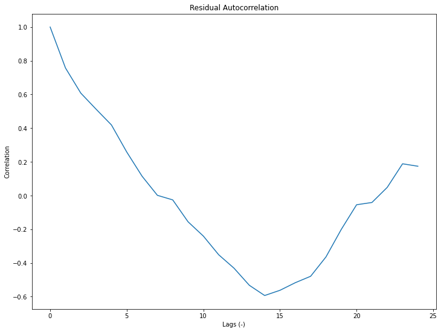

```
0
```

```python
get_best_lag(unemp_res_arr, unemp_res_arr, lags=25, x_label='Lags (-)', y_label='Correlation', title='Residual Autocorrelation')
```

There is still high autocorrelation, and from looking at the graph of unemployment it seems like there is a regime change after the elections in 2018. Therefore, adding binary feature about election (~fitting surrogate LRs) seems reasonable to explain the unemployment and remove yearly residual autocorrelations.

```python
# +- 2 months are experimented to find highest R^2 score
unemp_X['is_post_election'] = (linkdn_search_df['Date'].iloc[9:] > pd.to_datetime('2018-10-01')).astype(int)
```

```python
unemp_lr = sm.OLS(unemp_df['Unemployment Rate'].iloc[9:], unemp_X)
unemp_lr = unemp_lr.fit()
unemp_lr.summary()
```

OLS Regression Results

| Dep. Variable: | Unemployment Rate | R-squared: | 0.873 |
| --- | --- | --- | --- |
| Model: | OLS | Adj. R-squared: | 0.849 |
| Method: | Least Squares | F-statistic: | 35.87 |
| Date: | Fri, 05 Apr 2024 | Prob (F-statistic): | 4.86e-27 |
| Time: | 15:26:25 | Log-Likelihood: | -78.961 |
| No. Observations: | 88 | AIC: | 187.9 |
| Df Residuals: | 73 | BIC: | 225.1 |
| Df Model: | 14 |  |  |
| Covariance Type: | nonrobust |  |  |

|  | coef | std err | t | P>\|t\| | [0.025 | 0.975] |
| --- | --- | --- | --- | --- | --- | --- |
| const | 10.3673 | 0.779 | 13.310 | 0.000 | 8.815 | 11.920 |
| Job SS | 0.0150 | 0.007 | 2.043 | 0.045 | 0.000 | 0.030 |
| USD/TL | -3.1544 | 11.056 | -0.285 | 0.776 | -25.190 | 18.881 |
| Is Covid | 0.6505 | 0.176 | 3.692 | 0.000 | 0.299 | 1.002 |
| trend | -0.0784 | 0.007 | -10.991 | 0.000 | -0.093 | -0.064 |
| 1 | 1.5381 | 0.273 | 5.632 | 0.000 | 0.994 | 2.082 |
| 2 | 1.4481 | 0.286 | 5.059 | 0.000 | 0.878 | 2.019 |
| 3 | 0.6512 | 0.287 | 2.271 | 0.026 | 0.080 | 1.223 |
| 7 | 1.0312 | 0.287 | 3.595 | 0.001 | 0.460 | 1.603 |
| 8 | 0.7344 | 0.288 | 2.550 | 0.013 | 0.161 | 1.308 |
| 9 | 0.6879 | 0.294 | 2.340 | 0.022 | 0.102 | 1.274 |
| 10 | 0.7587 | 0.292 | 2.596 | 0.011 | 0.176 | 1.341 |
| 11 | 0.2569 | 0.284 | 0.906 | 0.368 | -0.308 | 0.822 |
| 12 | 0.7676 | 0.273 | 2.807 | 0.006 | 0.223 | 1.313 |
| is_post_election | 3.9505 | 0.384 | 10.276 | 0.000 | 3.184 | 4.717 |

| Omnibus: | 3.381 | Durbin-Watson: | 1.174 |
| --- | --- | --- | --- |
| Prob(Omnibus): | 0.184 | Jarque-Bera (JB): | 2.915 |
| Skew: | 0.442 | Prob(JB): | 0.233 |
| Kurtosis: | 3.109 | Cond. No. | 1.20e+04 |

Notes:  
[1] Standard Errors assume that the covariance matrix of the errors is correctly specified.  
[2] The condition number is large, 1.2e+04. This might indicate that there are  
strong multicollinearity or other numerical problems.

As we can see Adjusted R^2 value increased significantly and not USD/TL feature is no more needed because its effect is explained by the new binary feaure which is significant for this model.

```python
unemp_lr = sm.OLS(unemp_df['Unemployment Rate'].iloc[9:], unemp_X.drop('USD/TL', axis=1))
unemp_lr = unemp_lr.fit()
unemp_lr.summary()
```

OLS Regression Results

| Dep. Variable: | Unemployment Rate | R-squared: | 0.873 |
| --- | --- | --- | --- |
| Model: | OLS | Adj. R-squared: | 0.851 |
| Method: | Least Squares | F-statistic: | 39.11 |
| Date: | Fri, 05 Apr 2024 | Prob (F-statistic): | 7.89e-28 |
| Time: | 15:26:26 | Log-Likelihood: | -79.010 |
| No. Observations: | 88 | AIC: | 186.0 |
| Df Residuals: | 74 | BIC: | 220.7 |
| Df Model: | 13 |  |  |
| Covariance Type: | nonrobust |  |  |

|  | coef | std err | t | P>\|t\| | [0.025 | 0.975] |
| --- | --- | --- | --- | --- | --- | --- |
| const | 10.2105 | 0.548 | 18.619 | 0.000 | 9.118 | 11.303 |
| Job SS | 0.0154 | 0.007 | 2.165 | 0.034 | 0.001 | 0.030 |
| Is Covid | 0.6605 | 0.172 | 3.849 | 0.000 | 0.319 | 1.002 |
| trend | -0.0774 | 0.006 | -12.526 | 0.000 | -0.090 | -0.065 |
| 1 | 1.5351 | 0.271 | 5.660 | 0.000 | 0.995 | 2.075 |
| 2 | 1.4452 | 0.284 | 5.084 | 0.000 | 0.879 | 2.012 |
| 3 | 0.6469 | 0.285 | 2.273 | 0.026 | 0.080 | 1.214 |
| 7 | 1.0390 | 0.284 | 3.661 | 0.000 | 0.474 | 1.604 |
| 8 | 0.7439 | 0.284 | 2.617 | 0.011 | 0.177 | 1.310 |
| 9 | 0.7027 | 0.288 | 2.444 | 0.017 | 0.130 | 1.276 |
| 10 | 0.7688 | 0.288 | 2.666 | 0.009 | 0.194 | 1.343 |
| 11 | 0.2562 | 0.282 | 0.909 | 0.366 | -0.305 | 0.818 |
| 12 | 0.7624 | 0.271 | 2.812 | 0.006 | 0.222 | 1.303 |
| is_post_election | 4.0118 | 0.317 | 12.667 | 0.000 | 3.381 | 4.643 |

| Omnibus: | 3.623 | Durbin-Watson: | 1.187 |
| --- | --- | --- | --- |
| Prob(Omnibus): | 0.163 | Jarque-Bera (JB): | 3.060 |
| Skew: | 0.447 | Prob(JB): | 0.217 |
| Kurtosis: | 3.186 | Cond. No. | 693. |

Notes:  
[1] Standard Errors assume that the covariance matrix of the errors is correctly specified.

```python
unemp_X = unemp_X.drop('USD/TL', axis=1)
```

```python
unemp_res_arr = unemp_lr.resid
```

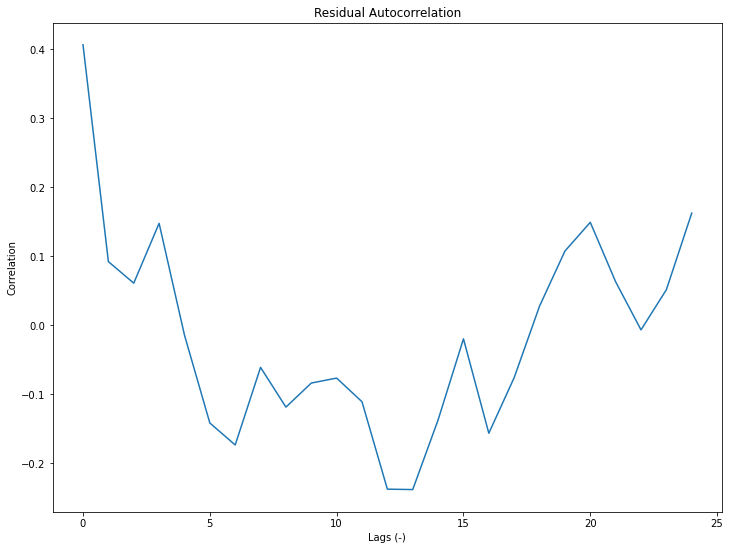

```
0
```

```python
get_best_lag(unemp_res_arr.shift(1).iloc[1:], unemp_res_arr.iloc[1:], lags=25, x_label='Lags (-)', y_label='Correlation', title='Residual Autocorrelation')
```

There is a hight correlation in lag 1 which indicates that there is important factors that explain unemployment which are not in this model. Other lag correlations seems fine and within a small band, further residual analysis is needed to check linear regression assumptions.

### Residual Analysis

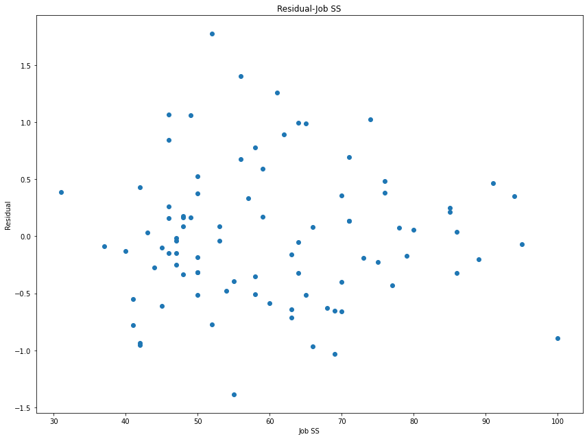

```python
fig, ax_arr = plt.subplots(nrows=1, ncols=1, figsize=(12, 9))

a = 1
for i in range(1):
    ax = ax_arr
    comp_feature = unemp_X.columns[a]
    ax.scatter(unemp_X[comp_feature], unemp_res_arr)
    ax.set_title('Residual-' + comp_feature)
    ax.set_xlabel(comp_feature)
    ax.set_ylabel('Residual')
    a+=1

plt.tight_layout()
plt.show()
```

No obvious pattern between the residuals and the job search in Google.

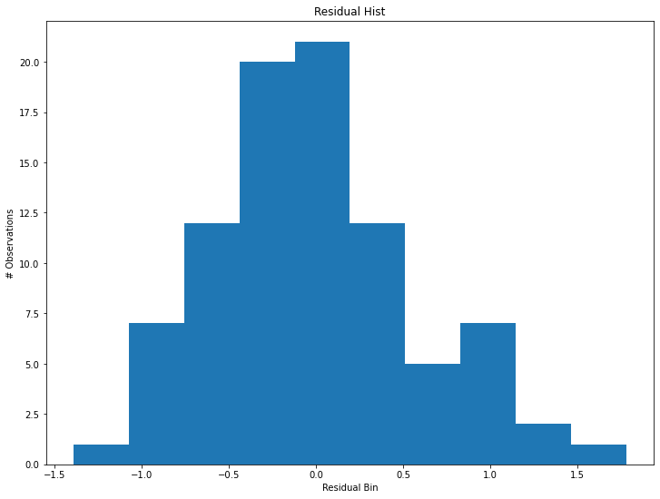

```python
plt.figure(figsize=(12, 9))
plt.title('Residual Hist')
plt.hist(unemp_res_arr)
plt.xlabel('Residual Bin')
plt.ylabel('# Observations')
```

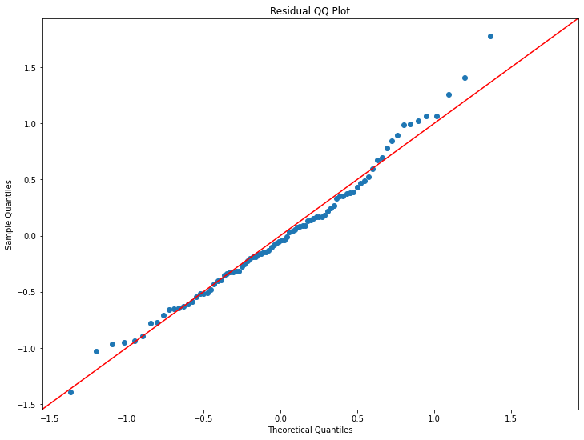

```python
plt.figure(figsize=(12, 9))
ax = plt.subplot()
sm.qqplot(unemp_res_arr, loc=0, scale=unemp_res_arr.std(), ax=ax, line='45')
plt.title('Residual QQ Plot')
plt.show()
```

Residuals seem to be distributed normally, even though there are some outliers.

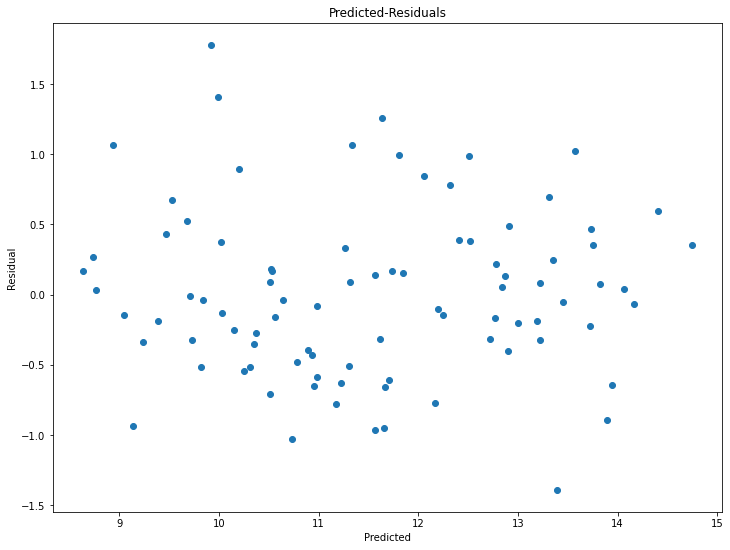

```python
plt.figure(figsize=(12, 9))
plt.scatter(unemp_lr.predict(unemp_X), unemp_res_arr)
plt.title('Predicted-Residuals')
plt.xlabel('Predicted')
plt.ylabel('Residual')
```

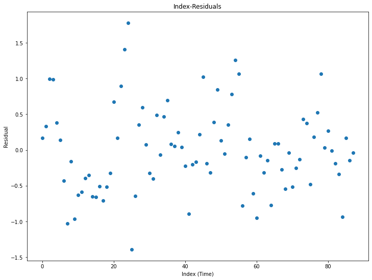

```python
plt.figure(figsize=(12, 9))
plt.scatter(range(len(unemp_res_arr)), unemp_res_arr)
plt.title('Index-Residuals')
plt.xlabel('Index (Time)')
plt.ylabel('Residual')
```

Variance of the residuals seems to be constant.

```python
sm.stats.acorr_ljungbox(unemp_res_arr, lags=[12], return_df=True)
```

|  | lb_stat | lb_pvalue |
| --- | --- | --- |
| 12 | 25.964384 | 0.010859 |

```python
sm.stats.acorr_ljungbox(unemp_res_arr, lags=[24], return_df=True)
```

|  | lb_stat | lb_pvalue |
| --- | --- | --- |
| 24 | 42.138476 | 0.012452 |

## Conclusion

The aim of this study was to analyze economical parameters in Turkey to explain their relations to other economical or social variables. Three analysis were done:

1- House Sales The main questions that were analyzed:

- Does online house search have impact on house sales? => Yes, significantly.
- Does online wedding hall search have impact on house sales? => Yes, significantly.
- Does online real estate search have impact on house sales? => Yes, however since other variables explains it, this feature is not significant for the model.
- Does online foreign house search have impact on house sales? => Yes, significantly.
- Did Covid-19 have an effect on housing? => Yes, significantly.
- Is there a trend or seasonality in the house sales? => Yes, significantly.

2- BIST Volume The main questions that were analyzed:

- Does interest rates have an effect on BIST volume? => Yes, significantly.
- Does online stock market search, impact BIST volume? => Yes, significantly.
- Does online gold search have an impact on BIST volume? => Yes, significantly.
- Does USD exchange rate have impact on BIST volume? => Yes, significantly.
- Is there a trend or seasonality in the BIST volume? => Yes, significantly.

Also to further improve the model, the binary feauture which indicates whether it is post election or not is added. This feature significantly improved the model which indicates that a pattern change happaned for the unemployment.